# Heatmap

Pumla

2024-06-26

#Setting up environment #Clean environment

```r
rm(list = ls(all.names = TRUE))
```

#load libraries

```r
library(DESeq2)
```

```r
library(pheatmap)
library(dplyr)
library(RColorBrewer)
library(ggplot2)
library(ggrepel)
```

#set the working directory

```r
setwd("~/starmm/heatmap")
```

#load the count data

```r
count_data <- read.csv('Counts.csv',header=TRUE,row.names=1)
```

#load the fpkm data

```r
fpkm_data <- read.csv('FPKM.csv', header=TRUE, row.names=1)
```

#check column names

```r
colnames(count_data)
```

```
## [1] "SRR13893218.bam" "SRR13893219.bam" "SRR13893220.bam" "SRR13893221.bam"
## [5] "SRR13893222.bam" "SRR13893223.bam"
```

```r
head(count_data, 50)
```

```
##                       SRR13893218.bam SRR13893219.bam SRR13893220.bam
## ENSMUSG00000000001.5             4853            5020            4433
## ENSMUSG00000000003.16               0               0               2
## ENSMUSG00000000028.16             267             271             155
## ENSMUSG00000000031.19               0               0               0
## ENSMUSG00000000037.18               0               0               0
## ENSMUSG00000000049.12              14              11              35
## ENSMUSG00000000056.8             1769            1702            1500
## ENSMUSG00000000058.7               85              86              73
## ENSMUSG00000000078.8            51187           51411           19277
## ENSMUSG00000000085.17             665             673             961
## ENSMUSG00000000088.8             1620            1582             315
## ENSMUSG00000000093.7               62              37              49
## ENSMUSG00000000094.13              45              26              25
## ENSMUSG00000000103.13              18              18               0
## ENSMUSG00000000120.7               21              10              23
## ENSMUSG00000000125.6               23              22              23
## ENSMUSG00000000126.12               0               1               0
## ENSMUSG00000000127.16              69              82              79
## ENSMUSG00000000131.16            3595            3557            3282
## ENSMUSG00000000134.18            1057            1032            1413
## ENSMUSG00000000142.16            1134            1136             741
## ENSMUSG00000000148.18             376             413             582
## ENSMUSG00000000149.11             311             328             387
## ENSMUSG00000000154.17              10               0               0
## ENSMUSG00000000157.17               0               0               0
## ENSMUSG00000000159.17              69              67              40
## ENSMUSG00000000167.15              47              52              65
## ENSMUSG00000000168.11            1320            1340            1844
## ENSMUSG00000000171.6             3726            3706            2961
## ENSMUSG00000000182.10               8              11               0
## ENSMUSG00000000183.7                2               1               6
## ENSMUSG00000000184.13           27552           27676           16697
## ENSMUSG00000000194.14            2236            2251            1944
## ENSMUSG00000000197.9                9              25              28
## ENSMUSG00000000202.10               0               0              13
## ENSMUSG00000000204.17              11              10               3
## ENSMUSG00000000214.12              17              20               0
## ENSMUSG00000000215.12               0               0               0
## ENSMUSG00000000216.9                5               5               4
```

[output cut: 47 more lines]

```
## ENSMUSG00000000204.17               7              32              23
## ENSMUSG00000000214.12               1               4               2
## ENSMUSG00000000215.12               0               4              16
## ENSMUSG00000000216.9                2               4              11
## ENSMUSG00000000223.14              21              67              82
## ENSMUSG00000000244.18           12747           10976           10867
## ENSMUSG00000000247.12               9              41              39
## ENSMUSG00000000248.17             233              76              38
## ENSMUSG00000000253.14              15              29              33
## ENSMUSG00000000263.16              23               0               0
## ENSMUSG00000000266.12               2              37              22
## ENSMUSG00000000275.17            1850            1081            1171
## ENSMUSG00000000276.12            1146             500             474
## ENSMUSG00000000278.11            1402            1109            1143
## ENSMUSG00000000282.13            1425            1477            1361
```

#load the sample information

```r
sample_info <- read.csv('Design.csv',header=TRUE,row.names=1)
```

#ensure there are no missing values in your count data

```r
sum(is.na(count_data))
```

```
## [1] 0
```

```r
sum(is.na(sample_info))
```

```
## [1] 0
```

#set factor levels

```r
sample_info$Treatment <- factor(sample_info$Treatment)
```

#create a deseq object and import the count data and sample information

```r
dds <- DESeqDataSetFromMatrix(countData = count_data,colData = sample_info, design = ~Treatment)
```

```r
dds$Treatment <- factor(dds$Treatment, levels = c("healthy", "treated"))
```

#filter the genes based on count per sample

```r
keep <- rowSums(counts(dds) >= 10) >= 3
dds <- dds[keep,]
```

#perform the statistical test(s) to identify differentially expressed genes

```r
dds <- DESeq(dds)
deseq_result <- results(dds)
deseq_result
```

```
## log2 fold change (MLE): Treatment treated vs healthy
## Wald test p-value: Treatment treated vs healthy
## DataFrame with 24187 rows and 6 columns
##                        baseMean log2FoldChange     lfcSE       stat      pvalue
##                       <numeric>      <numeric> <numeric>  <numeric>   <numeric>
## ENSMUSG00000000001.5  4940.7415      0.2864192 0.0659722   4.341516 1.41503e-05
## ENSMUSG00000000028.16  243.7970      0.5601987 0.2762332   2.027992 4.25610e-02
## ENSMUSG00000000049.12   25.2133      0.1971360 0.7062459   0.279132 7.80143e-01
## ENSMUSG00000000056.8  1637.8456      0.1593566 0.1023288   1.557301 1.19399e-01
## ENSMUSG00000000058.7    82.5624      0.0511158 0.2313707   0.220926 8.25150e-01
## ...                         ...            ...       ...        ...         ...
## ENSMUSG00002076905.1    13.4466      2.2596820  1.342143  1.6836377 0.092251715
## ENSMUSG00002076924.1    13.8675     -0.1317237  0.658407 -0.2000645 0.841430169
## ENSMUSG00002076935.1    14.3309     -1.0157755  0.614096 -1.6540989 0.098107429
## ENSMUSG00002076943.1   122.8292     -0.8496965  0.218575 -3.8874397 0.000101307
## ENSMUSG00002076957.1    23.2221     -0.0181544  0.438431 -0.0414077 0.966970898
##                              padj
##                         <numeric>
## ENSMUSG00000000001.5  0.000189502
## ENSMUSG00000000028.16 0.126768911
## ENSMUSG00000000049.12 0.884186775
## ENSMUSG00000000056.8  0.269257562
## ENSMUSG00000000058.7  0.910326053
## ...                           ...
## ENSMUSG00002076905.1   0.22394861
## ENSMUSG00002076924.1   0.91985310
## ENSMUSG00002076935.1   0.23386815
## ENSMUSG00002076943.1   0.00100505
## ENSMUSG00002076957.1   0.98454938
```

#change DESeq Object to R object(dataframe)

```r
deseq_result <- as.data.frame(deseq_result)
class(deseq_result)
```

```
## [1] "data.frame"
```

```r
head(deseq_result, 50)
```

```
##                          baseMean log2FoldChange      lfcSE       stat
## ENSMUSG00000000001.5   4940.74148     0.28641920 0.06597217  4.3415156
## ENSMUSG00000000028.16   243.79704     0.56019872 0.27623318  2.0279921
## ENSMUSG00000000049.12    25.21325     0.19713603 0.70624587  0.2791323
## ENSMUSG00000000056.8   1637.84556     0.15935664 0.10232876  1.5573006
## ENSMUSG00000000058.7     82.56238     0.05111581 0.23137067  0.2209261
## ENSMUSG00000000078.8  32574.05921    -0.23464970 0.44175303 -0.5311785
## ENSMUSG00000000085.17   655.46010    -1.35176717 0.29473663 -4.5863562
## ENSMUSG00000000088.8    807.50922    -0.65272572 0.69570528 -0.9382216
## ENSMUSG00000000093.7     60.10732     1.01074481 0.35641026  2.8359026
## ENSMUSG00000000094.13    37.16251     0.77841712 0.43029464  1.8090328
## ENSMUSG00000000120.7     21.67256     0.46501814 0.56701552  0.8201154
## ENSMUSG00000000125.6     21.54753    -0.31616276 0.43731370 -0.7229656
## ENSMUSG00000000127.16    71.74155    -0.30349729 0.26143565 -1.1608872
## ENSMUSG00000000131.16  3371.04933    -0.03088292 0.06429047 -0.4803655
## ENSMUSG00000000134.18  1155.05174    -0.26074782 0.24615371 -1.0592886
## ENSMUSG00000000142.16   891.46521    -0.14070773 0.21802515 -0.6453739
## ENSMUSG00000000148.18   440.46654    -0.58321727 0.31180177 -1.8704745
## ENSMUSG00000000149.11   367.48054     0.14617674 0.23764363  0.6151090
## ENSMUSG00000000159.17    63.51471     0.79171868 0.39655724  1.9964802
## ENSMUSG00000000167.15    50.60618    -0.13268495 0.33550254 -0.3954812
## ENSMUSG00000000168.11  1533.04804    -0.10456382 0.25109497 -0.4164314
## ENSMUSG00000000171.6   3455.08024     0.17435768 0.10730811  1.6248323
## ENSMUSG00000000184.13 27956.55675     0.90821123 0.24731101  3.6723446
## ENSMUSG00000000194.14  2152.66788     0.21218937 0.08964215  2.3670713
## ENSMUSG00000000197.9     22.99918     0.32195991 0.63515030  0.5069035
## ENSMUSG00000000202.10    14.35948     1.82467299 1.78278359  1.0234966
## ENSMUSG00000000204.17    14.19911     1.85746003 0.65935632  2.8170808
## ENSMUSG00000000223.14    34.06698     2.43580707 0.57515731  4.2350276
## ENSMUSG00000000244.18 10166.89926     0.15823570 0.37953938  0.4169151
## ENSMUSG00000000247.12    19.05800     2.21511538 0.51551193  4.2969236
## ENSMUSG00000000248.17   106.26499    -1.19843028 0.90959640 -1.3175407
## ENSMUSG00000000253.14    29.61332     0.09785644 0.48332424  0.2024654
## ENSMUSG00000000263.16    13.96627    -6.82842551 1.54144085 -4.4298979
## ENSMUSG00000000266.12    14.00188     2.22704651 0.84004176  2.6511140
## ENSMUSG00000000275.17  1383.04723    -0.42431570 0.29180104 -1.4541267
## ENSMUSG00000000276.12   728.40877    -0.80147357 0.42287903 -1.8952786
## ENSMUSG00000000278.11  1244.75544    -0.21126477 0.21709392 -0.9731492
## ENSMUSG00000000282.13  1443.22324    -0.03585763 0.11862189 -0.3022851
## ENSMUSG00000000290.14 14013.60851     0.88306204 0.05799596 15.2262692
```

[output cut: 47 more lines]

```
## ENSMUSG00000000276.12 5.805550e-02 1.587836e-01
## ENSMUSG00000000278.11 3.304792e-01 5.341483e-01
## ENSMUSG00000000282.13 7.624348e-01 8.736238e-01
## ENSMUSG00000000290.14 2.367199e-52 1.363168e-49
## ENSMUSG00000000295.14 1.713235e-06 2.996117e-05
## ENSMUSG00000000296.9  1.881472e-01 3.687325e-01
## ENSMUSG00000000301.17 8.099290e-02 2.038391e-01
## ENSMUSG00000000303.14 5.662882e-06 8.438199e-05
## ENSMUSG00000000305.13 5.209938e-01 7.032075e-01
## ENSMUSG00000000317.12 3.316738e-03 1.719216e-02
## ENSMUSG00000000318.17 1.145021e-04 1.108626e-03
## ENSMUSG00000000320.11 7.344870e-01 8.576817e-01
## ENSMUSG00000000326.14 5.652160e-01 7.379785e-01
## ENSMUSG00000000339.15 1.582936e-01 3.275252e-01
## ENSMUSG00000000340.11 8.921870e-01 9.472627e-01
```

#Order the results table by increasing p-value (the lowest p-value first, most statistically significant appearing first)

```r
deseq_result_ordered <- deseq_result[order(deseq_result$pvalue),]
head(deseq_result_ordered, 50)
```

```
##                         baseMean log2FoldChange      lfcSE      stat
## ENSMUSG00000029075.7   2076.2072       4.452573 0.12158942  36.61974
## ENSMUSG00000014599.11  2349.9634       3.534876 0.09861396  35.84560
## ENSMUSG00000052336.9    916.2648       4.941661 0.14512585  34.05087
## ENSMUSG00000120236.1    779.3325       5.334278 0.18370261  29.03757
## ENSMUSG00000020027.19  8887.4673      -1.581802 0.06079194 -26.01993
## ENSMUSG00000022479.16   452.5805       4.206086 0.16651778  25.25908
## ENSMUSG00000045087.9   1001.9165       4.715235 0.18970600  24.85548
## ENSMUSG00000030114.9   2026.6448       4.115173 0.17794985  23.12546
## ENSMUSG00000085519.2    323.8071       5.238612 0.23005728  22.77090
## ENSMUSG00000002808.8    274.6626       4.809432 0.21220525  22.66406
## ENSMUSG00000054072.13   713.5329       2.572797 0.11530372  22.31322
## ENSMUSG00000121360.1    471.2840       2.752828 0.12936445  21.27963
## ENSMUSG00000030122.14  8628.4086       2.717416 0.13139180  20.68178
## ENSMUSG00000022225.8    298.0095       4.866629 0.23764011  20.47899
## ENSMUSG00000042379.9    348.0039       4.983788 0.24730384  20.15249
## ENSMUSG00000030124.3   4765.7327       5.394516 0.26895763  20.05712
## ENSMUSG00000021760.6    287.1132       5.784085 0.29114610  19.86661
## ENSMUSG00000051212.9   5945.5003      -1.294828 0.06544037 -19.78638
## ENSMUSG00000046718.9   8223.8601      -1.072555 0.05647495 -18.99170
## ENSMUSG00000004709.15  2786.1174       1.226720 0.06782663  18.08611
## ENSMUSG00000079173.12   335.5736       2.705028 0.15260469  17.72572
## ENSMUSG00000032437.11  5834.2989      -1.098931 0.06286153 -17.48178
## ENSMUSG00000038151.14  1283.2678       1.481746 0.08523803  17.38362
## ENSMUSG00000103432.2   2329.7476       1.357492 0.07814026  17.37251
## ENSMUSG00000016529.6   1830.8565       5.666638 0.32660119  17.35033
## ENSMUSG00000026011.14  1681.9142       5.179801 0.30278465  17.10721
## ENSMUSG00000024098.7   1111.2187       2.946263 0.17398281  16.93422
## ENSMUSG00000011831.17   419.1118      -2.654277 0.15809423 -16.78921
## ENSMUSG00000029530.17  1953.7160      -3.574650 0.21422232 -16.68664
## ENSMUSG00000021477.10  1064.2444      -2.190954 0.13259743 -16.52335
## ENSMUSG00000053310.12  1797.0246       4.926630 0.30422521  16.19402
## ENSMUSG00000033016.17  5551.1794       1.229466 0.07608863  16.15834
## ENSMUSG00000009588.10  1544.6623       2.172499 0.13576922  16.00141
## ENSMUSG00000068923.15  1335.1236       1.894018 0.11848425  15.98540
## ENSMUSG00000044303.7    236.9349       2.632930 0.16499928  15.95722
## ENSMUSG00000035133.10  1851.0608      -1.334943 0.08469477 -15.76181
## ENSMUSG00000030154.11  1537.9887       1.425054 0.09082232  15.69057
## ENSMUSG00000018012.12   297.9473       5.155052 0.32939026  15.65029
## ENSMUSG00000028634.18  2632.0357       1.171643 0.07491355  15.63993
```

[output cut: 47 more lines]

```
## ENSMUSG00000035133.10  5.697805e-56  3.827975e-53
## ENSMUSG00000030154.11  1.754777e-55  1.147055e-52
## ENSMUSG00000018012.12  3.307211e-55  2.104953e-52
## ENSMUSG00000028634.18  3.891282e-55  2.413193e-52
## ENSMUSG00000067219.10  6.690103e-54  4.045171e-51
## ENSMUSG00000095522.3   5.214789e-53  3.076217e-50
## ENSMUSG00000000290.14  2.367199e-52  1.363168e-49
## ENSMUSG00000027072.14  3.453869e-51  1.942681e-48
## ENSMUSG00000028565.19  4.906861e-51  2.697212e-48
## ENSMUSG00000035021.15  8.573065e-51  4.607737e-48
## ENSMUSG00000032446.15  8.960251e-51  4.711144e-48
## ENSMUSG00000049109.16  2.974171e-50  1.530496e-47
## ENSMUSG00000103693.2   7.358477e-50  3.707753e-47
## ENSMUSG00000063903.6   8.035118e-50  3.966069e-47
## ENSMUSG00000021411.17  5.683818e-49  2.749376e-46
```

#extract the most differentially expressed genes due to the treatment #select genes with a significant change in gene expression (adjusted p-value below 0.05) #And log2fold change <1 and >1

#step 1: filter based on p adjusted values

```r
filtered <- deseq_result %>% filter(deseq_result$padj < 0.05)
```

#step 2: filter based on fold changes. here we will use a threshold of 1

```r
filtered <- filtered %>% filter(abs(filtered$log2FoldChange) > 1)
```

```r
dim(deseq_result)
```

```
## [1] 24187     6
```

```r
dim(filtered)   #those that are differentially expressed
```

```
## [1] 3407    6
```

```r
write.csv(deseq_result,'de_results.all.csv')
write.csv(deseq_result,'de_results.filtered.csv')
```

#visualization #Heatmap

# Select top 30 genes with the lowest p-values

```r
top_hits <- row.names(deseq_result_ordered)[1:30]
```

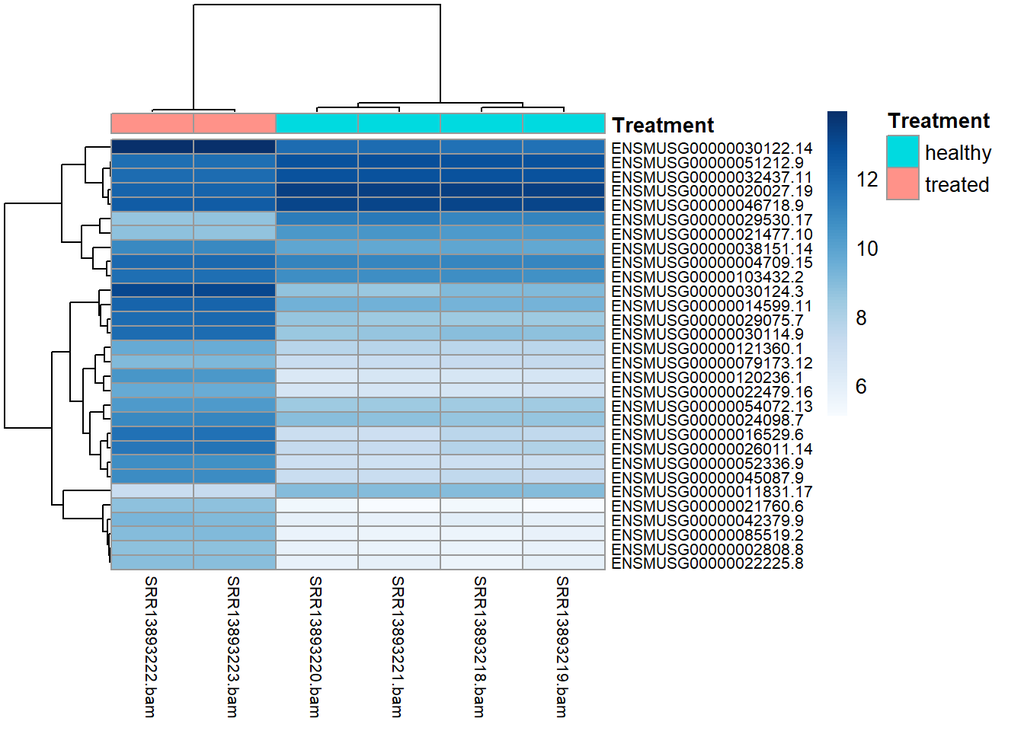

```r
rld <- rlog(dds, blind=FALSE)
pheatmap(assay(rld)[top_hits,],
         cluster_rows=TRUE,
         show_rownames=TRUE,
         cluster_cols=TRUE,
         annotation_col=sample_info,
         color=colorRampPalette(brewer.pal(9, "Blues"))(100),
         fontsize_row=8,
         fontsize_col=8)
```

#Log transform FPKM data

```r
log_fpkm_data <- log2(fpkm_data + 1)
```

#Calculate Z-scores

```r
cal_z_score <- function(x) {(x - mean(x)) / sd(x)}
zscore_all <- t(apply(log_fpkm_data, 1, cal_z_score))
zscore_subset <- zscore_all[top_hits,]
```

#Heatmap of log-transformed FPKM values for the top 30 genes

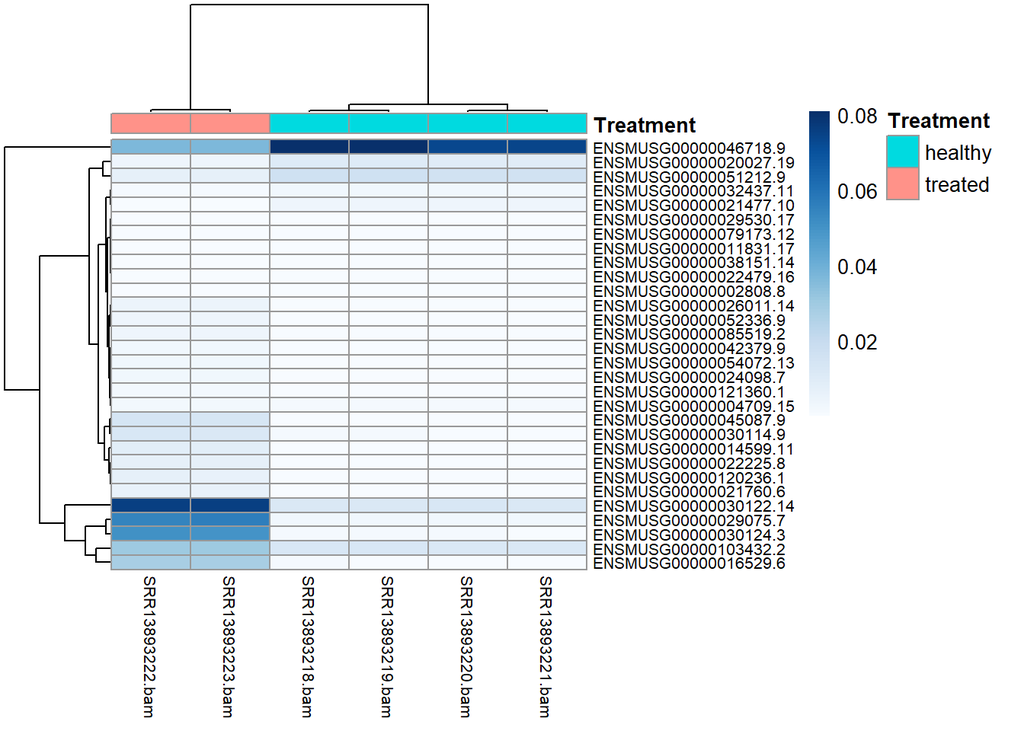

```r
pheatmap(log_fpkm_data[top_hits,],
         cluster_rows=TRUE,
         show_rownames=TRUE,
         cluster_cols=TRUE,
         annotation_col=sample_info,
         color=colorRampPalette(brewer.pal(9, "Blues"))(100),
         fontsize_row=8,
         fontsize_col=8)
```

#Heatmap of Z-scores for the top 30 genes

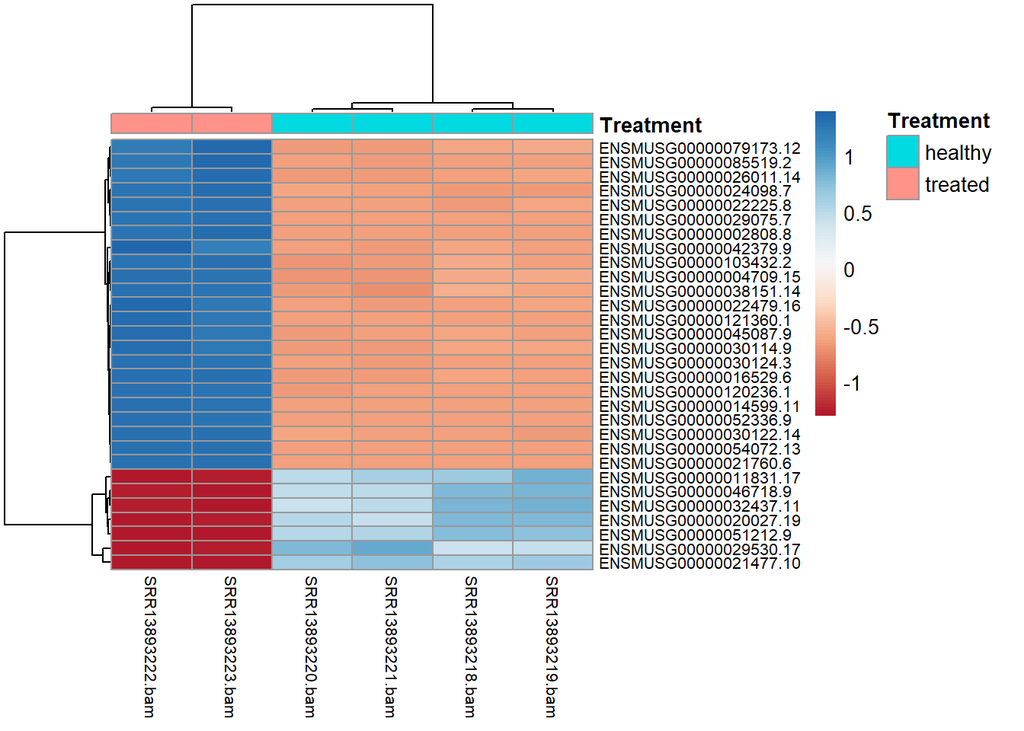

```r
pheatmap(zscore_subset,
         cluster_rows=TRUE,
         show_rownames=TRUE,
         cluster_cols=TRUE,
         annotation_col=sample_info,
         color=colorRampPalette(brewer.pal(9, "RdBu"))(100),
         fontsize_row=8,
         fontsize_col=8)
```

#Select Top 30 Genes with the Lowest Adjusted p-Values (padj) # Order results by padj (adjusted p-value)

```r
deseq_result_ordered <- deseq_result[order(deseq_result$padj),]
```

#Select top 30 genes with the lowest padj values

```r
top_hits <- row.names(deseq_result_ordered)[1:30]
```

#Perform regularized log transformation

```r
rld <- rlog(dds, blind=FALSE)
```

#Heatmap of log-transformed counts for the top 30 genes

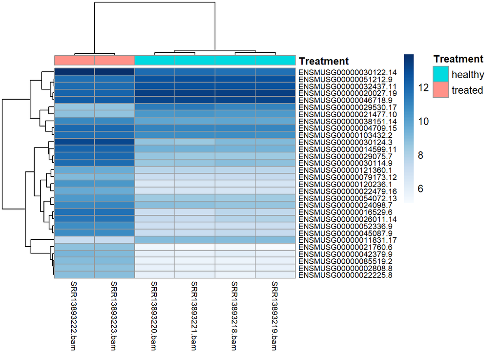

```r
pheatmap(assay(rld)[top_hits,],
         cluster_rows=TRUE,
         show_rownames=TRUE,
         cluster_cols=TRUE,
         annotation_col=sample_info,
         color=colorRampPalette(brewer.pal(9, "Blues"))(100),
         fontsize_row=8,
         fontsize_col=8)
```